# PLPA6820_Study

Kylie Blake

2025-03-04

## Quiz Activity: R Programming Basics

Question 1: Subsetting Data Using the subset function: How would you create a subset of the iris dataset where Species is “virginica”?

```r
data("iris")
subset(iris[iris$Species=="virginica",])
```

```
##     Sepal.Length Sepal.Width Petal.Length Petal.Width   Species
## 101          6.3         3.3          6.0         2.5 virginica
## 102          5.8         2.7          5.1         1.9 virginica
## 103          7.1         3.0          5.9         2.1 virginica
## 104          6.3         2.9          5.6         1.8 virginica
## 105          6.5         3.0          5.8         2.2 virginica
## 106          7.6         3.0          6.6         2.1 virginica
## 107          4.9         2.5          4.5         1.7 virginica
## 108          7.3         2.9          6.3         1.8 virginica
## 109          6.7         2.5          5.8         1.8 virginica
## 110          7.2         3.6          6.1         2.5 virginica
## 111          6.5         3.2          5.1         2.0 virginica
## 112          6.4         2.7          5.3         1.9 virginica
## 113          6.8         3.0          5.5         2.1 virginica
## 114          5.7         2.5          5.0         2.0 virginica
```

[output cut: 36 more lines]

```r
#can also do
subset(iris, Species == "virginica")
```

```
##     Sepal.Length Sepal.Width Petal.Length Petal.Width   Species
## 101          6.3         3.3          6.0         2.5 virginica
## 102          5.8         2.7          5.1         1.9 virginica
## 103          7.1         3.0          5.9         2.1 virginica
## 104          6.3         2.9          5.6         1.8 virginica
## 105          6.5         3.0          5.8         2.2 virginica
## 106          7.6         3.0          6.6         2.1 virginica
## 107          4.9         2.5          4.5         1.7 virginica
## 108          7.3         2.9          6.3         1.8 virginica
## 109          6.7         2.5          5.8         1.8 virginica
## 110          7.2         3.6          6.1         2.5 virginica
## 111          6.5         3.2          5.1         2.0 virginica
## 112          6.4         2.7          5.3         1.9 virginica
## 113          6.8         3.0          5.5         2.1 virginica
## 114          5.7         2.5          5.0         2.0 virginica
```

[output cut: 36 more lines]

Without using the subset function: How would you create the same subset using indexing?

```r
subset <- (iris[iris$Species=="virginica",])
```

Question 2: Mathematical Functions How would you calculate the median of Sepal.Width for the entire iris dataset?

```r
median(iris$Sepal.Width)
```

```
## [1] 3
```

How would you find the variance of Petal.Length for the “setosa” species?

```r
setosa_subset <- subset(iris, Species == "setosa")
var(setosa_subset$Petal.Length)
```

```
## [1] 0.03015918
```

Question 3: Data Visualization with ggplot2 How would you create a histogram of Sepal.Length using ggplot2?

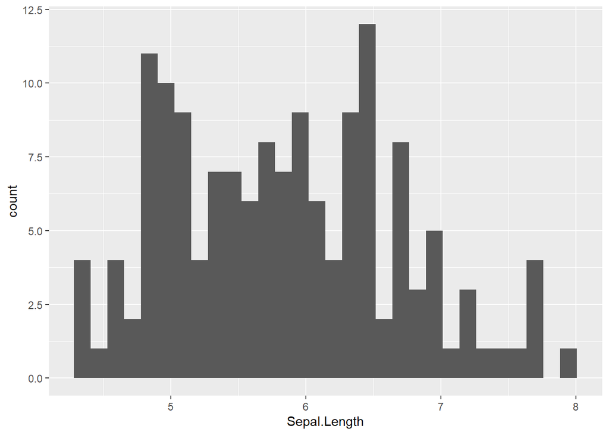

```r
library(ggplot2)
ggplot(iris, aes(x=Sepal.Length))+
  geom_histogram()
```

How would you create a line plot of Petal.Width vs Petal.Length, colored by Species?

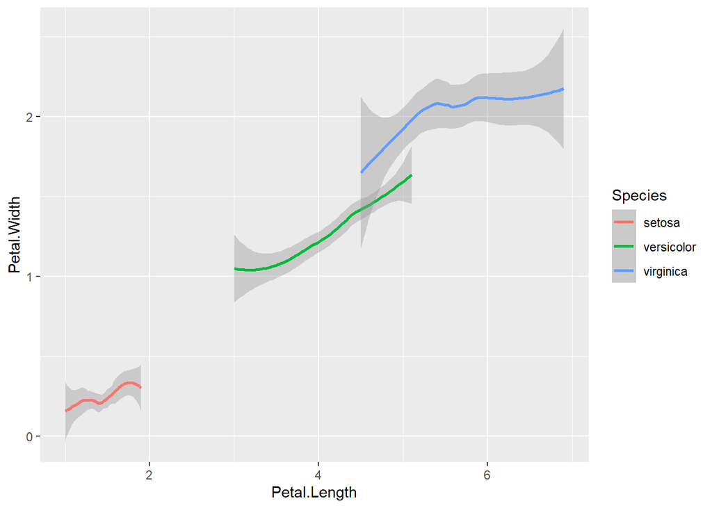

```r
ggplot(iris, aes(x=Petal.Length, y=Petal.Width, color=Species))+
  geom_smooth()
```

## Extended Quiz Activity: R Programming Basics Question 1: Subsetting Data Using the subset function: How would you create a subset of the iris dataset where Sepal.Length is greater than 6?

```r
subset_Sepal.Length <- subset(iris, Sepal.Length >6)
subset_Sepal.Length2 <- iris[iris$Sepal.Length>6,]
```

Without using the subset function: How would you create the same subset using indexing?

```r
subset_Sepal.Length2 <- iris[iris$Sepal.Length>6,]
```

Using the dplyr package: How would you create a subset of the iris dataset where Petal.Width is less than 1.5?

```r
library(dplyr)
iris %>%
  filter(Petal.Width<1.5)
```

```
##    Sepal.Length Sepal.Width Petal.Length Petal.Width    Species
## 1           5.1         3.5          1.4         0.2     setosa
## 2           4.9         3.0          1.4         0.2     setosa
## 3           4.7         3.2          1.3         0.2     setosa
## 4           4.6         3.1          1.5         0.2     setosa
## 5           5.0         3.6          1.4         0.2     setosa
## 6           5.4         3.9          1.7         0.4     setosa
## 7           4.6         3.4          1.4         0.3     setosa
## 8           5.0         3.4          1.5         0.2     setosa
## 9           4.4         2.9          1.4         0.2     setosa
## 10          4.9         3.1          1.5         0.1     setosa
## 11          5.4         3.7          1.5         0.2     setosa
## 12          4.8         3.4          1.6         0.2     setosa
## 13          4.8         3.0          1.4         0.1     setosa
## 14          4.3         3.0          1.1         0.1     setosa
```

[output cut: 72 more lines]

Question 2: Mathematical Functions How would you calculate the range of Sepal.Width for the entire iris dataset?

```r
range(iris$Sepal.Width)
```

```
## [1] 2.0 4.4
```

How would you find the interquartile range (IQR) of Petal.Length for the “versicolor” species?

```r
subset_PL <- iris[iris$Species == "versicolor",]
IQR(subset_PL$Petal.Length)
```

```
## [1] 0.6
```

How would you calculate the sum of Sepal.Length for the “setosa” species?

```r
subset_SL <- iris[iris$Species == "setosa",]
iris_SL <- subset(iris, Species == "setosa")
sum(subset_SL$Sepal.Length)
```

```
## [1] 250.3
```

```r
sum(iris_SL$Sepal.Length)
```

```
## [1] 250.3
```

Question 3: Data Manipulation Using the dplyr package: How would you add a new column to the iris dataset that contains the ratio of Sepal.Length to Sepal.Width?

```r
library(dplyr)
iris_new <- iris %>%
  mutate(Sepal.Ratio = Sepal.Length/Sepal.Width)
```

Using the dplyr package: How would you group the iris dataset by Species and calculate the mean Petal.Length for each species?

```r
library(dplyr)

mean_PL <- iris %>%
  group_by(Species) %>%
  summarise(mean_PL = mean(Petal.Length))
```

Question 4: Data Visualization with ggplot2 How would you create a bar plot of the count of each Species using ggplot2?

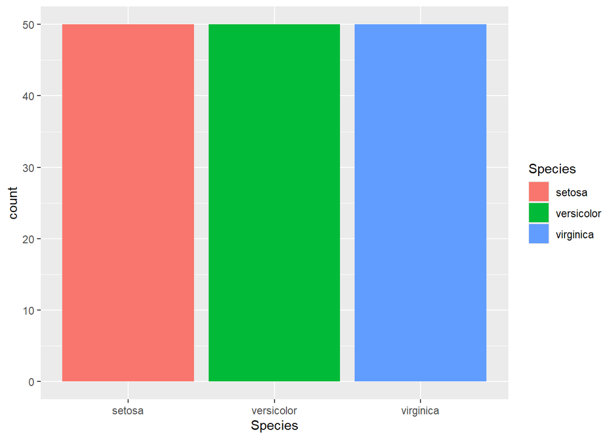

```r
ggplot(iris, aes(x=Species, fill=Species))+
  geom_bar()+
  labs(x="Species", y="count")
```

How would you create a density plot of Sepal.Length, filled by Species?

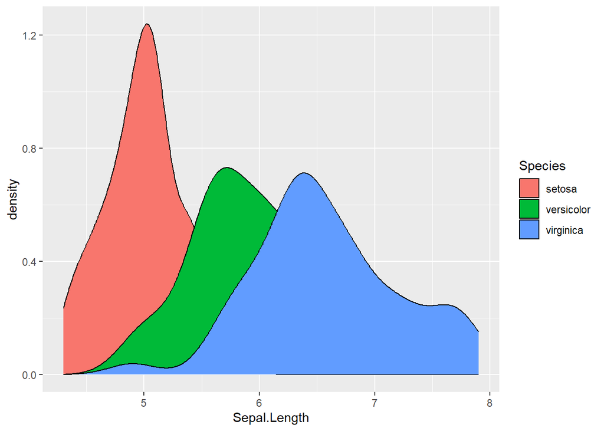

```r
ggplot(iris, aes(x=Sepal.Length, fill = Species))+
  geom_density()
```

How would you create a faceted scatter plot of Petal.Length vs Petal.Width, with each facet representing a different Species?

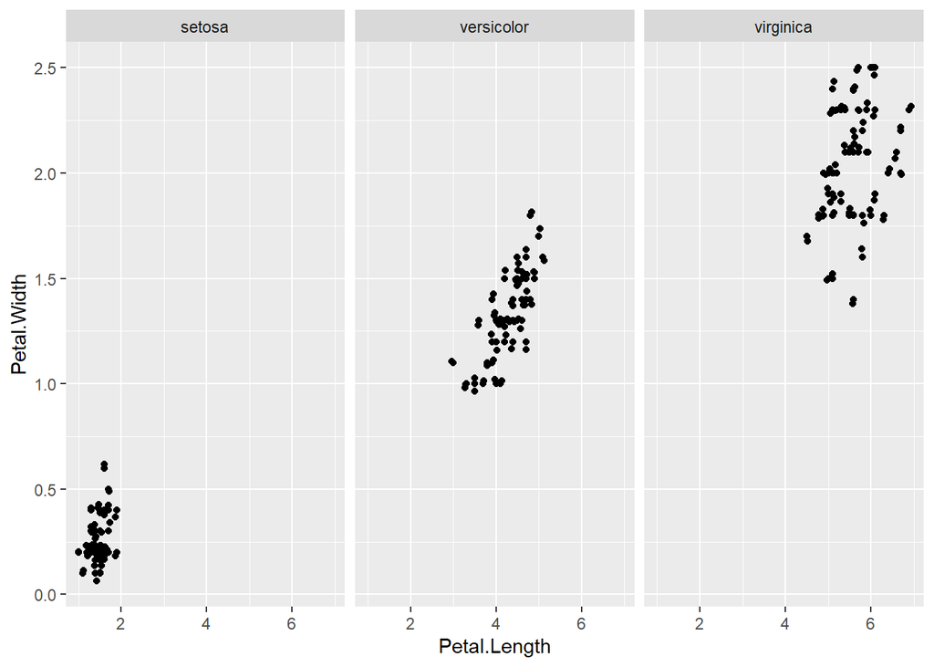

```r
ggplot(iris, aes(x=Petal.Length, y=Petal.Width))+
  geom_point()+
  geom_jitter() +
  facet_wrap(~Species)
```